# DATA 606 Final Project

Wei Zhou

### Data Preparation

```r
# load data
library(dplyr)
library(nycflights13)
library(ggplot2)

head(flights,10)
names(flights)
```

[output not shown]

### Research question

**You should phrase your research question in a way that matches up with the scope of inference your dataset allows for.**

Is there any relationship between origin airport and and probability of delay?

** Why do you care? Why should others care?** Working as a consultant, one will spend a good amount of time in Airport. If the research indicates there is a relationship between departure airport and probability of delay, one can consider the airport factor to avoid potential delay.

## Data

### Cases

**What are the cases, and how many are there?**

```r
nrow(flights)
```

```
## [1] 336776
```

```r
summary(flights$year)
```

```
##    Min. 1st Qu.  Median    Mean 3rd Qu.    Max.
##    2013    2013    2013    2013    2013    2013
```

Cases are each flights information departure from EWR,JFK,LGA in 2013.

The are 336776 cases.

### Data collection

**Describe the method of data collection.**

**If you collected the data, state self-collected. If not, provide a citation/link.**

https://github.com/hadley/nycflights13

### Type of study

**What type of study is this (observational/experiment)?**

Observational study

### Variables

**Dependent Variable: What is the response variable? Is it quantitative or qualitative?**

The response variable is airline delay or not

```r
flights=flights%>%
  mutate(dep_delay_bool=ifelse(dep_delay>=0,'ontime','delay'))
class(flights$dep_delay_bool)
```

```
## [1] "character"
```

**Independent Variable: You should have two independent variables, one quantitative and one qualitative.**

```r
class(flights$origin)
```

```
## [1] "character"
```

### Scope of inference

**generalizability: Identify the population of interest, and whether the findings from this analysis can be generalized to that population, or, if not, a subsection of that population. Explain why or why not. Also discuss any potential sources of bias that might prevent generalizability.**

Population of interest: Flights departure from NYC airport. The finding from this analys can be generalized to the population.

**causality: Can these data be used to establish causal links between the variables of interest? Explain why or why not.** These data cannot be used to establish causal links between the origin airport and departure delay. Chi-square test can only indicate correlationship between two categorical relationship.

### Exploratory data analysis:

#### Relevant summary statistics

**Provide summary statistics for each the variables. Also include appropriate visualizations related to your research question (e.g. scatter plot, boxplots, etc). This step requires the use of R, hence a code chunk is provided below. Insert more code chunks as needed.**

#### Delay proportion

```r
table(flights$dep_delay_bool)
```

```
##
##  delay ontime
## 183575 144946
```

```r
prop.table(table(flights$dep_delay_bool))
```

```
##
##     delay    ontime
## 0.5587923 0.4412077
```

**Barchart showing the proportion of departure delay and on time.**

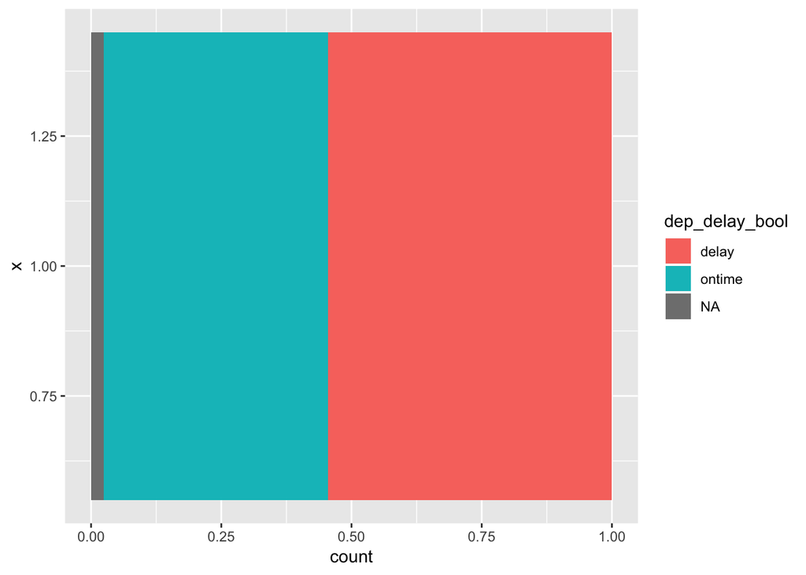

```r
ggplot(flights,aes(1 ,fill =dep_delay_bool )) +
    geom_bar(position = "fill")+
    coord_flip()
```

#### number of flights by each departure airport

**EWR had the most flights comparing to JFK and LGA**

```r
table(flights$origin)
```

```
##
##    EWR    JFK    LGA
## 120835 111279 104662
```

```r
prop.table(table(flights$origin))
```

```
##
##       EWR       JFK       LGA
## 0.3587993 0.3304244 0.3107763
```

#### Contingency table : Airport v.s. Delay

```r
table(flights$origin, flights$dep_delay_bool)
```

```
##
##       delay ontime
##   EWR 59300  58296
##   JFK 61146  48270
##   LGA 63129  38380
```

```r
prop.table(table(flights$origin, flights$dep_delay_bool),1)
```

```
##
##           delay    ontime
##   EWR 0.5042689 0.4957311
##   JFK 0.5588397 0.4411603
##   LGA 0.6219054 0.3780946
```

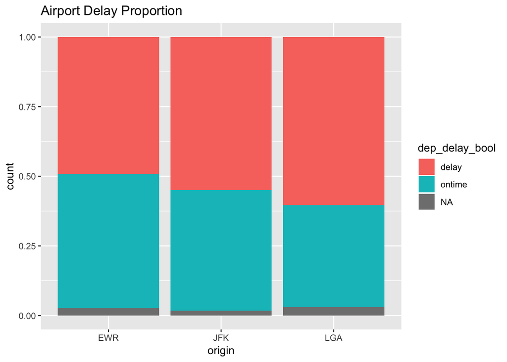

```r
ggplot(flights,aes(origin ,fill =dep_delay_bool )) +
    geom_bar(position = "fill")+
    ggtitle("Airport Delay Proportion")
```

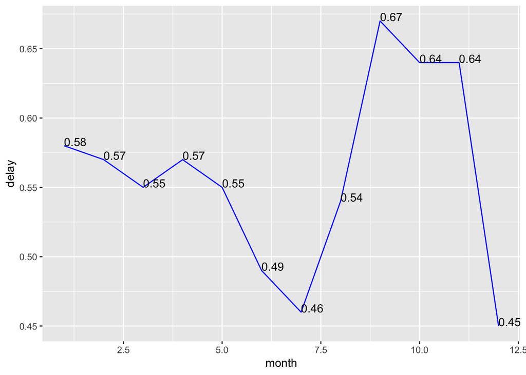

```r
flights%>%
  na.omit()%>%
  mutate(delay_rate = ifelse(dep_delay_bool=='delay',1,0))%>%
  group_by(month)%>%
  summarize(delay = round(mean(delay_rate),2))%>%
  ggplot(aes(month,delay))+
  geom_line(color='blue')+
  geom_text(aes(label=delay),hjust=0, vjust=0)
```

### Inference

#### Chi-square test

To test the relationship between Origin Airport and Delay using Pearson’s Chi-square test, we need to set null and alternative hypothesis:

Null Hypothesis: The Origin Airport and Departure Delay Senario are independent with each other Alternative Hypothesis: The Origin Airport and Departure Delay Senario are not independent with each other

```r
chi_sq_tbl=table(flights$origin, flights$dep_delay_bool)
chisq.test(chi_sq_tbl)
```

```
##
##  Pearson's Chi-squared test
##
## data:  chi_sq_tbl
## X-squared = 3058, df = 2, p-value < 2.2e-16
```

From the above result, we can see that p-value is less than the significance level (0.05). Therefore, we can reject the null hypothesis and conclude that the two variables (Origin Airport & Departure Delay) are not independent.

### Conclusion

Given the result of Chi-square test, we can conclude that the origin airport and delayed departure are not independent with each other. Thus, if you are on a time sensitive business trip, it is important to take Origin Airport as a factor to avoid potential departure delay. In the future research, it is also interesting to explore how time (Year,Month,hour) and weather affect departure delay.